# Entresto Journey at 10 — Mobile Reader

Entresto @ 10Mobile Reader · TSOC 2026

Novartis Cardio-Renal Program · Sacubitril / Valsartan · ARNI Class

## Entresto Journey at Ten

From landmark trials to real-world outcomes — closing the evidence gap.

2014–2026

Span of Evidence

PARADIGM

Landmark

PIONEER

In-hospital

PARAGON

Preserved EF

TSOC 2026 · A Decade of Cardio-Renal Synergy · For Healthcare Professionals Only

§ Agenda — Eight Movements

## What we will cover

01

The Entresto Story

A decade of transforming heart failure care.

02

Mechanism of Action

Dual cardio-renal synergy of Sacubitril / Valsartan.

03

Landmark Trials

PARADIGM-HF, PIONEER-HF, PARAGON-HF.

04

New Evidence — PREMIER & RWE

Japan PREMIER, Swedish & US real-world data.

05

Across the CKD Spectrum

Normal eGFR → CKD 3b → ESKD / Dialysis.

06

De Novo HFrEF

Early initiation benefits in treatment-naïve patients.

07

Real-World Evidence

SwedeHF, US Optum, TAROT-HF, meta-analyses.

08

2024 Guidelines & Practice

ACC ECDP positioning & actionable dosing.

§ 01 · The Entresto Story

## A decade of innovation

From landmark trials to real-world outcomes · 2014 — 2025.

2014

Trial

PARADIGM-HF published (NEJM)

2015

Regulatory

FDA approval for HFrEF

2016

Guideline

ESC — Class I recommendation

2018

Trial

PIONEER-HF in-hospital · UK-HARP-III

2019

Trial

PARAGON-HF (LVEF ≥45%)

2021

Regulatory

FDA expanded indication

2023

Trial

PARAGLIDE-HF

2024

Guideline

ACC ECDP 1st line; Japan PREMIER

2025

Real-World

Dialysis meta-analyses & US Optum RWE

**參考文獻 References**

McMurray JJV. PARADIGM-HF. NEJM 2014;371:993-1004 (PMID 25176015) · Velazquez EJ. PIONEER-HF. NEJM 2019;380:539-548 (PMID 30415601) · Solomon SD. PARAGON-HF. NEJM 2019;381:1609-1620 (PMID 31475794) · Maddox TM. 2024 ACC ECDP. JACC 2024;83(15):1444-88 (PMID 38466244) · Tanaka A. PREMIER. Eur Heart J 2024;45(42):4482-93 (PMID 39215531).

Chapter 02 · Mechanism of Action

## Two pathways, one molecule

Neprilysin inhibition meets RAAS blockade — the dual-acting basis of every benefit that follows.

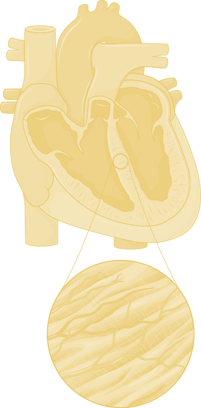

§ 02 · What is ARNI?

## Sacubitril / Valsartan

A first-in-class dual-acting neurohormonal modulator.

Sacubitril — Neprilysin Inhibitor

- Blocks degradation of natriuretic peptides (ANP, BNP, CNP)
- Increases bradykinin levels

→ Natriuresis · Vasodilation · Anti-fibrosis

Valsartan — AT₁ Receptor Blocker

- Blocks angiotensin II at the AT₁ receptor
- Inhibits RAAS over-activation

→ ↓ Aldosterone · Anti-remodeling

Dual neurohormonal pathway → ↑ Natriuresis · ↓ Fibrosis · ↓ Afterload · ↓ Remodeling = Synergy & dual protection.

**參考文獻 References**

Vardeny O, Miller R, Solomon SD. Combined neprilysin & RAS inhibition for HF. JACC Heart Fail 2014;2(6):663-70 (PMID 25306450) · McMurray JJV. PARADIGM-HF. NEJM 2014;371:993-1004 (PMID 25176015).

§ 02 · Foundation of Synergy

## Why ARNI protects the kidney

| Component | Target | Effect |
| --- | --- | --- |
| Sacubitril | Neprilysin inhibition | ↑ NP (ANP, BNP) · ↑ Bradykinin → Natriuresis, vasodilation, anti-fibrosis |
| Valsartan | AT₁ receptor blockade | Inhibits RAAS → ↓ Aldosterone, anti-remodeling |
| Combined | Dual neurohormonal | NP enhancement + RAAS suppression → cardio-renal protection |

#### Why this matters for the kidney

- Natriuretic peptides are endogenous renal protectors.
- Promote afferent arteriolar vasodilation → ↓ intraglomerular pressure.
- Combined with efferent vasodilation → dual glomerular protection.
- Anti-fibrotic effects reduce tubulo-interstitial fibrosis.

Two arterioles, one principle — NP relax the afferent, Valsartan relaxes the efferent; the glomerulus is decompressed from both sides.

**參考文獻 References**

Packer M. Circulation 2015;131(1):54-61 (PMID 25403646) · Damman K. PARADIGM-HF renal effects. JACC Heart Fail 2018;6(6):489-98 (PMID 29655829) · Judge P. Neprilysin inhibition in CKD. NDT 2015;30(5):738-43 (PMID 25140014).

§ 02 · The Concept Born from a Failure

## The drug that almost wasn’t

Omapatrilat — the late-1990s vasopeptidase inhibitor that blocked both ACE and neprilysin.

| **OVERTURE (2002)** | Chronic HF, n=5,770. Omapatrilat not superior to enalapril. |
| --- | --- |
| **OCTAVE (2004)** | Hypertension, n=25,302. Angioedema 3.0× higher vs enalapril (2.17% vs 0.68%). |
| **FDA decision** | 2002 — Refused approval. Vasopeptidase inhibition abandoned. |

#### The design lesson that gave us ARNI

- Bradykinin is degraded by both ACE and NEP.
- Block both → bradykinin accumulates → angioedema risk soars.
- Solution: pair NEP inhibition with an **ARB**, not an ACEi — spare ACE so bradykinin still has a clearance pathway.
- Novartis embodied this in LCZ696 — sacubitril co-crystallised 1:1 with valsartan.

One ACE-inhibitor decision — replaced by an ARB — turned a failed drug class into a Class I therapy.

**參考文獻 References**

Packer M. OVERTURE. Circulation 2002;106(8):920-6 (PMID 12186794) · Kostis JB. OCTAVE. Am J Hypertens 2004;17(2):103-11 (PMID 14751650) · Hubers SA, Brown NJ. Circulation 2016;133(11):1115-24 (PMID 26976916).

§ 02 · The Phase 2 Stepping Stone

## PARAMOUNT — the trial that earned two Phase 3s

| Trial | PARAMOUNT (Solomon SD et al.) |
| --- | --- |
| Year | Lancet 2012;380:1387-95 |
| Population | 301 patients · LVEF ≥ 45% |
| Comparator | LCZ696 vs valsartan, 36 weeks |
| Primary | NT-proBNP change at week 12 |
| Result | Pre-specified primary met (p = 0.005) |

#### Why PARAMOUNT mattered

- First clinical confirmation that pairing NEP-i with an ARB was tolerable — no angioedema excess.
- Provided the regulatory rationale to launch PARADIGM-HF (HFrEF) → positive 2014, and PARAGON-HF (LVEF ≥45%) → near-miss 2019.
- Established NT-proBNP as a Phase 2 surrogate — still used today (PIONEER, PARAGLIDE, PREMIER).

**參考文獻 References**

Solomon SD. PARAMOUNT. Lancet 2012;380(9851):1387-95 (PMID 22932717) · Eadie AL. Pharmacol Res Perspect 2021;9(3):e00794 (PMID 34087050).

§ 03 · The Landmark Trial

## PARADIGM-HF — stopped early for overwhelming benefit

8,442

N randomized

HFrEF (LVEF ≤40%)

0.80

HR — primary

↓20% CV death / HF hosp

↓16%

All-cause mortality

HR 0.84

21

NNT

primary endpoint

| Endpoint | HR | RRR | NNT |
| --- | --- | --- | --- |
| CV death or HF hospitalization | 0.80 | ↓20% | 21 |
| CV death | 0.80 | ↓20% | 32 |
| All-cause mortality | 0.84 | ↓16% | 36 |
| HF hospitalization | 0.79 | ↓21% | — |

Sacubitril/Valsartan vs Enalapril · median follow-up 27 months · stopped early for efficacy.

**參考文獻 References**

McMurray JJV. ARNI vs Enalapril in HF (PARADIGM-HF). NEJM 2014;371:993-1004 (PMID 25176015).

§ 03 · Survival without HF Hospitalisation

0.80

HR — primary

CV death + HF hosp · 95% CI 0.73–0.87

4.7%

ARR — primary

26.5% → 21.8%

27 mo

Median F/U

stopped early for benefit

21

NNT

over 27 months

**參考文獻 References**

§ 03 · The Field that PARADIGM Created

## One trial in 2014 → 2,607 peer-reviewed papers by 2026

2,607

Total publications

PubMed 2010–2026

386

Peak year 2022

2025 still 332

- 2014 → 2022: a 12-fold increase in annual output, peaking with the AHA/ACC/HFSA Class I HFrEF guideline.
- 2024-25: literature shifts from RCTs to real-world cohorts (Swedish nationwide, US Optum) and Asian-specific data (PREMIER, KorAHF, TSOC).
- Now includes paediatrics (PANORAMA-HF), dialysis (Nguyen 2025 SRMA), MR (PRIME), peripartum CMP, dystrophinopathy — well beyond classic HFrEF.

PubMed search 2026-05-10: ("sacubitril/valsartan" OR "LCZ696" OR "Entresto"). 2026 = Jan–May (annualised projection ~315).

§ 03 · Beyond PARADIGM-HF

## An expanding evidence base

| Trial | Year | Population | Key finding |
| --- | --- | --- | --- |
| PARADIGM-HF | 2014 | HFrEF (n=8,442) | ↓20% CV death / HF hosp vs enalapril |
| PIONEER-HF | 2019 | Acute decompensated HF (n=881) | ↓29% NT-proBNP; safe in-hospital initiation |
| PARAGON-HF | 2019 | LVEF ≥45% (n=4,822) | Trend to benefit; significant in LVEF ≤57% |
| PARAGLIDE-HF | 2023 | LVEF >40%, post-decomp (n=466) | ↓NT-proBNP vs valsartan; fewer renal events |
| UK-HARP-III | 2018 | CKD 3b-4 (n=414) | No adverse renal effect; ↓BP, ↓cardiac markers |
| PREMIER | 2024 | Asian AHF (n=400) | In-hospital initiation effective in Asian population |

**參考文獻 References**

McMurray NEJM 2014 (PMID 25176015) · Velazquez NEJM 2019 (PMID 30415601) · Solomon NEJM 2019 (PMID 31475794) · Mentz JACC 2023;82(1):1-12 (PMID 37212758) · Haynes UK-HARP-III. Circulation 2018;138(15):1505-14 (PMID 30002098) · Tanaka EHJ 2024;45(42):4482-93 (PMID 39215531).

§ 03 · Effect Sizes Across the Programme

## A decade of trials — one direction

Hazard ratio (95% CI) — every point estimate sits at or below HR 1.0.

| Trial / cohort | HR (95% CI) | Population (year) |
| --- | --- | --- |
| PARADIGM-HF | **0.80 (0.73–0.87)** | HFrEF ≤40%, n=8,442 (2014) |
| PIONEER-HF | **0.54 (0.37–0.79)** | ADHF in-hospital, n=881 (2019) |
| PARAGON-HF | 0.87 (0.75–1.01) | LVEF ≥45%, n=4,822 (2019) |
| PARADISE-MI | 0.90 (0.78–1.04) | Post-AMI, n=5,661 (2021) |
| PARAGLIDE-HF | 0.85 (0.73–0.999) | LVEF >40% worsening HF, n=466 (2023) |
| PREMIER (JP) | **0.69 (0.55–0.86)** | Asian AHF (LVEF<40), n=400 (2024) |
| SwedeHF (Fu) | **0.77 (0.63–0.95)** | Sweden registry, n=1,506 PS-matched (2023) |
| Optum De Novo | **0.70 (0.62–0.79)** | First-Rx HFrEF, n=9,870 (2025) |

**參考文獻 References**

McMurray NEJM 2014 (PMID 25176015) · Velazquez NEJM 2019 (PMID 30415601) · Solomon NEJM 2019 (PMID 31475794) · Pfeffer PARADISE-MI NEJM 2021 (PMID 34758252) · Mentz JACC 2023 (PMID 37212758) · Tanaka EHJ 2024 (PMID 39215531) · Fu SwedeHF. Clin Res Cardiol 2023;112(1):167-74 (PMID 36443599) · Bhatt ESC HF 2025;12(3):1682-92 (PMID 39888167).

§ 03 · Safe In-Hospital Initiation

## PIONEER-HF — start before discharge

−46.7%

NT-proBNP (8 wk)

vs −25.3% enalapril

0.54

Composite HR

death / HF / LVAD / Tx · NNT 13

| Outcome | S/V | Enalapril | Difference |
| --- | --- | --- | --- |
| NT-proBNP reduction (8 wk) | −46.7% | −25.3% | ↓29% greater |
| Worsening renal function | 13.6% | 14.7% | No difference |
| Symptomatic hypotension | 15.0% | 12.7% | NS |
| Composite (death/HF rehosp/LVAD/Tx) | HR 0.54 |  | NNT = 13 |

In-hospital initiation during a stabilized acute HF episode (n=881). Early initiation is safe and drives faster reverse remodeling.

**參考文獻 References**

Velazquez EJ. PIONEER-HF. NEJM 2019;380:539-548 (PMID 30415601) · DeVore AD. PIONEER-HF OLE. JAMA Cardiol 2020;5(2):202-7 (PMID 31825471).

§ 03 · In-Hospital Initiation

881

N randomised

stabilised acute HF

0.54

Composite HR

95% CI 0.37–0.79

−29%

NT-proBNP Δ

vs enalapril, 8 wk

13

NNT

over 8 weeks

**參考文獻 References**

§ 04 · New Evidence

## Japan PREMIER — an Asian acute-HF population

Tanaka A, Eur Heart J 2024 — the first major Asian trial confirming in-hospital Sac/Val initiation benefits.

| Design | Multicenter, randomized, open-label, blinded-endpoint (PROBE) |
| --- | --- |
| Population | 400 Japanese inpatients stabilized after AHF, irrespective of LVEF |
| Intervention | Sac/Val vs ACEi or ARB |
| Primary endpoint | 8-week proportional change in geometric means of NT-proBNP |

76

Age (mean)

years

61%

SGLT2i therapy

at baseline

~75%

β-blocker

at baseline

~75%

MRA

at baseline

**參考文獻 References**

Tanaka A. Japan PREMIER Trial. Eur Heart J 2024;45(42):4482-93 (PMID 39215531).

§ 04 · Up-Titration Drives Benefit

## NT-proBNP reduction — greater with MRA and titration

−51%

With titration

NT-proBNP at week 8 · p=0.002

−39%

Without titration

NT-proBNP at week 8

p=0.037

MRA interaction

greater reduction

| Up-titration subgroup (Doi 2025) | NT-proBNP Δ (wk 8) | p vs ctrl |
| --- | --- | --- |
| Sac/Val with titration | −51% | 0.002 |
| Sac/Val without titration | −39% | 0.46 |
| ACEi / ARB control | Reference | — |

LVEF <40% subgroup HR 0.69 (0.55–0.86), p-interaction 0.1. Up-titration to target dose maximizes biomarker benefit.

**參考文獻 References**

Tanaka A. PREMIER. Eur Heart J 2024;45(42):4482-93 (PMID 39215531) · Doi S. PREMIER up-titration. J Card Fail 2026;32(3):573-82 (PMID 40389107).

§ 04 · Safety Profile

## Safe and well-tolerated in Asian acute HF

| Adverse event | Sac/Val (n=195) | Control (n=199) | HR (95% CI) |
| --- | --- | --- | --- |
| Composite (WHF or death) | 6.2% | 8.5% | 0.73 (0.35–1.52) |
| Worsening renal function | 19 events | 15 events | 1.33 (NS) |
| Hyperkalemia (K⁺ ≥5.5) | 12 events | 14 events | 0.90 (NS) |
| Symptomatic hypotension | 4 events | 9 events | 0.47 (NS) |

- eGFR change at week 8 — significantly greater in the Sac/Val with up-titration group.
- Serum potassium — no significant increase with Sac/Val.

Asian AHF patients tolerated in-hospital Sac/Val as well as, or better than, standard ACEi/ARB.

**參考文獻 References**

Tanaka A. Japan PREMIER. Eur Heart J 2024;45(42):4482-93 (PMID 39215531) · Doi S. J Card Fail 2026;32(3):573-82 (PMID 40389107).

§ 04 · 2025 Pooled Analysis

## ARNI after acute decompensation — pooling three RCTs

1,741

Patients pooled

868 ARNI · 873 ACEI/ARB

3

Randomized trials

PIONEER · PARAGLIDE · PREMIER

8 wk

Follow-up

Sac/Val 24/26 → 97/103 mg BID

Low

Risk of bias

all 3 RCTs (Cochrane RoB-2)

| Trial | Country | N | Comparator | LVEF |
| --- | --- | --- | --- | --- |
| PIONEER-HF — Velazquez 2019 | USA | 881 | Enalapril 10 mg BID | ≤40% |
| PARAGLIDE-HF — Mentz 2023 | USA & Canada | 466 | Valsartan 160 mg BID | >40% |
| PREMIER — Tanaka 2024 | Japan | 394 | Continue ACEI/ARB | Any |

PRISMA: 1,156 records → 3 RCTs included. ARNI initiated after stabilisation (SBP ≥100 mmHg, off IV support).

**參考文獻 References**

Taha HI, Shubietah A, Al Zoubi BM, et al. ARNI in acute decompensated HF: a meta-analysis of RCTs. Future Cardiol 2026;22(1):43-55 (PMID 40689605) · PROSPERO CRD42024618027.

§ 04 · Primary Outcomes

## Fewer rehospitalizations — a 29% drop in the composite

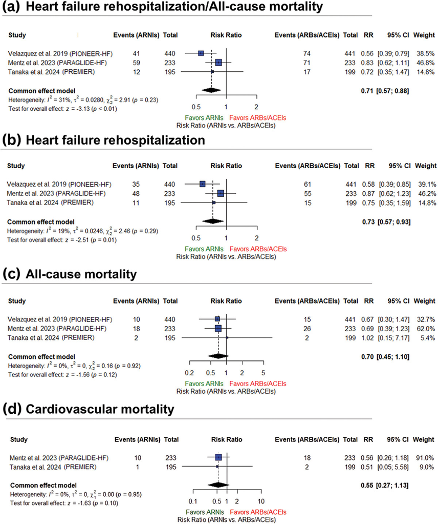

Risk Ratio (ARNI vs ARBs/ACEIs), common-effect model. Boxes left of 1.0 favour ARNI.

| Endpoint | RR (95% CI) | p | I² |
| --- | --- | --- | --- |
| Composite primary (HF rehosp / all-cause mortality) | 0.71 (0.57–0.88) | <0.01 | 31% |
| HF rehospitalization | 0.73 (0.57–0.93) | 0.01 | 19% |
| All-cause mortality | 0.70 (0.45–1.10) | 0.12 | 0% |
| Cardiovascular mortality | 0.55 (0.27–1.13) | 0.10 | 0% |

Benefit driven by fewer HF rehospitalizations. Mortality endpoints trend toward ARNI but underpowered at 8 weeks. Moderate GRADE certainty for composite & rehospitalization.

**參考文獻 References**

Taha HI, et al. Future Cardiol 2026;22(1):43-55 (PMID 40689605) · PROSPERO CRD42024618027.

§ 04 · Biomarker & Safety

## Deeper NT-proBNP fall — watch for hypotension

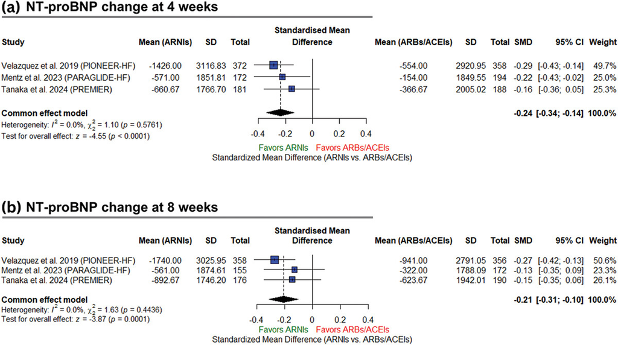

−0.24

NT-proBNP Δ 4 wk (SMD)

95% CI −0.34 to −0.14 · p<0.0001

−0.21

NT-proBNP Δ 8 wk (SMD)

95% CI −0.31 to −0.10 · p=0.0001

| Safety / secondary outcome | RR (95% CI) | p |
| --- | --- | --- |
| Worsening renal function ▼ favours ARNI | 0.80 (0.64–1.00) | 0.048 |
| Symptomatic hypotension ▲ higher with ARNI | 1.33 (1.04–1.71) | 0.024 |
| Hyperkalemia (>5.5 mEq/L) | 1.14 (0.87–1.49) | 0.35 |
| Angioedema | 0.30 (0.07–1.29) | 0.11 |
| Discontinuation due to AEs | 1.12 (0.88–1.43) | 0.34 |

**參考文獻 References**

Taha HI, et al. Future Cardiol 2026;22(1):43-55 (PMID 40689605) · PROSPERO CRD42024618027.

§ 04 · Real-World Evidence

## Swedish nationwide — 23% lower all-cause mortality with ARNI

Fu M et al. SwedeHF Registry. Clin Res Cardiol 2023 (PMID 36443599).

| Design | Nationwide registry, propensity-score-matched cohort |
| --- | --- |
| Population | HF with LVEF <50% (reduced or mildly reduced EF), 2016–2020 |
| Cohort | 7,275 ARNI eligible vs 24,604 ACEi/ARB eligible |
| Matched | 1,506 ARNI vs 1,506 ACEi/ARB (1:1 PS-matched) |

| Endpoint | HR (95% CI) | p |
| --- | --- | --- |
| All-cause mortality | 0.77 (0.63–0.95) | 0.013 |
| CV mortality | 0.77 (0.54–1.09) | 0.13 (NS) |
| All-cause hospitalization | 1.02 (0.91–1.13) | NS |
| CV hospitalization | 1.01 (0.91–1.15) | NS |

Real-world Nordic registry confirms the PARADIGM-HF mortality signal — consistent across European care settings.

**參考文獻 References**

Fu M, Pivodic A, Käck O, Costa-Scharplatz M, Dahlström U, Lund LH. Real-world ARNI vs ACEi/ARB in HF with reduced or mildly reduced EF (SwedeHF). Clin Res Cardiol 2023;112(1):167-174 (PMID 36443599).

§ 04 · De Novo HFrEF

## US real-world — first-line ARNI reduces all-cause hospitalization 19%

Bhatt AS et al. ESC Heart Fail 2025 (PMID 39888167) · US Optum EHR 2016–2020.

↓19%

All-cause hosp.

IRR 0.81 · Primary

↓20%

CV hosp.

IRR 0.80 · Secondary

↓14%

HF hosp.

IRR 0.86 · Secondary

↓30%

Mortality

IRR 0.70 · Exploratory

| Database | US Optum EHR (2016–2020), ~97M patients |
| --- | --- |
| Population | 3,290 ARNI vs 6,580 ACEi/ARB (1:2 PS-matched) de novo HFrEF (LVEF 10–40%, dx ≤30 days) |

Fewer all-cause deaths with Sac/Val (IRR 0.70, 95% CI 0.62–0.79, P<0.001), reported as exploratory; the all-cause hospitalization benefit was attenuated in patients ≥75 years (p-interaction by age = 0.001).

**參考文獻 References**

Bhatt AS, Vaduganathan M, Jena BP, et al. Real-world Sac/Val vs RAS inhibition in de novo HF (US Optum). ESC Heart Fail 2025;12(3):1682-1692 (PMID 39888167).

§ 06 · Early ARNI — Super-Responders

## De novo HFrEF patients are super-responders

| PIONEER-HF subgroup (JACC 2020) | NT-proBNP Δ | CV death / HF rehosp |
| --- | --- | --- |
| De novo HFrEF | Greater reduction | Lower incidence |
| Prior HFrEF | Reduction | Standard benefit |

| TRANSITION (Eur J Heart Fail 2020) | De novo | Prior HFrEF |
| --- | --- | --- |
| NT-proBNP decrease | Greater | Standard |
| HF rehospitalization | Fewer events | Standard |
| Composite endpoint | Fewer events | Standard |

Treatment-naïve hearts reward early, aggressive neurohormonal modulation with the greatest reverse remodeling.

**參考文獻 References**

Ambrosy AP. PIONEER-HF de novo subgroup. JACC 2020;76(9):1034-48 (PMID 32854838) · Wachter R. TRANSITION. Eur J Heart Fail 2019;21(8):998-1007 (PMID 31134724).

Entresto® at Ten · 24 / 40

§ 06 · Case Study A

## Early aggressive intervention — reverse remodeling at 12 months

|  | Baseline | 12-month |
| --- | --- | --- |
| Patient | 56 yo F, de novo DCMP · simultaneous 4-pillar GDMT |  |
| LVEF | 20% | 48% (↑28% abs.) |
| NT-proBNP | 6,230 pg/mL | 185 pg/mL (↓97%) |
| NYHA | III | I |
| 6MWT | — | +200 m |
| MR | Moderate functional | Trace |

Entresto 49/51 → 97/103 mg BID over 4 wks.

#### Why super-responders emerge

- Young DCMP patients have massive reverse-remodeling potential.
- 4-pillar GDMT synergy — ARNI + β-blocker + MRA + SGLT2i.
- 2024 ACC: early ARNI initiation without prior ACEi/ARB.

**參考文獻 References**

Illustrative case (institutional data) · 2024 ACC ECDP (Maddox TM). JACC 2024;83(15):1444-88 (PMID 38466244) · Heidenreich PA. Circulation 2022;145(18):e895-e1032 (PMID 35363499).

Chapter 05 · The Cardio-Renal Continuum

## Following ARNI into the kidney

From preserved eGFR to dialysis — one axis, protected end to end.

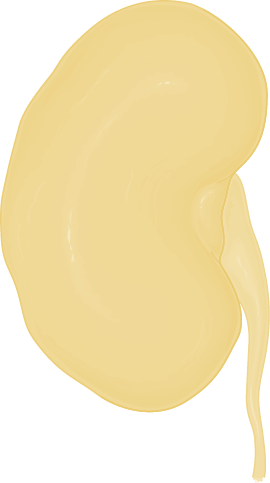

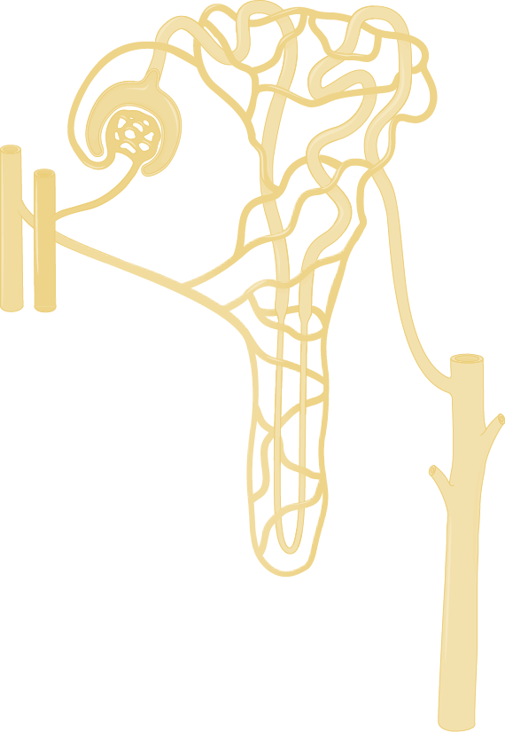

§ 05 · Three Clinical Scenarios

## Navigating the cardio-renal clinical spectrum

Declining renal function: Normal (eGFR ≥60) → CKD 3 (30–59) → CKD 4–5 (15–29) → ESKD (<15 / HD).

A

Normal eGFR

The de novo HF super-responder — young patient, maximal remodeling potential.

B

CKD 3b (eGFR 30–59)

Breaking the CKD prescribing barrier — the most under-treated population.

C

ESKD / Dialysis (eGFR <15)

Pushing the boundaries of safety — where evidence was historically absent.

**參考文獻 References**

Chatur S. Sac/Val across renal impairment (KDIGO). JACC 2024;83(22):2148-59 (PMID 38588927) · Haynes R. UK-HARP-III. Circulation 2018;138(15):1505-14 (PMID 30002098) · Nguyen DV. Dialysis SRMA. Eur J Heart Fail 2025;27(1):72-84 (PMID 39252524).

§ 05 · Case B · CKD 3b

## Breaking the CKD prescribing barrier

|  | Baseline | 6-month |
| --- | --- | --- |
| Patient | 78 yo M · ICMP + CKD 3b · ramipril stopped (36 h washout) |  |
| eGFR | 35 | 33 (stable) |
| LVEF | 25% | 33% (↑8%) |
| NYHA | III | II |
| MR EROA | 0.25 cm² | 0.15 cm² |

Low-dose Entresto 24/26 mg BID → titrated to 97/103 mg BID over 8 wks.

| eGFR range | % on ARNI (illustrative) | Evidence |
| --- | --- | --- |
| ≥60 | ~45% | High |
| 30–59 | ~25% | High (underused) |
| <30 | ~8% | Growing |
| Dialysis | ~3% | Emerging |

Illustrative gradient — composite of registry estimates. **The barrier is fear, not evidence.**

**參考文獻 References**

Illustrative case (institutional data) · Greene SJ. CHAMP-HF. JACC 2018;72(4):351-66 (PMID 30025570) · Zahir Anjum D. HF therapy initiation by kidney function (Danish nationwide). Clin Epidemiol 2023;15:855-66 (PMID 37489222).

§ 05 · Glomerular Hemodynamics

## Two arterioles, one principle

Sacubitril · ↑ ANP/BNP

Afferent arteriolar vasodilation

Valsartan · ↓ Angiotensin II

Efferent arteriolar vasodilation

The result — ↓ intraglomerular pressure + ↓ renal fibrosis → long-term nephroprotection (decompression from both sides).

#### PARADIGM-HF renal data

**參考文獻 References**

Damman K. Renal effects of ARNI in PARADIGM-HF. JACC Heart Fail 2018;6(6):489-98 (PMID 29655829) · Packer M. Circulation 2015;131(1):54-61 (PMID 25403646) · Judge P. NDT 2015;30(5):738-43 (PMID 25140014).

§ 05 · Consistent Efficacy

## Efficacy holds across every KDIGO risk tier

| PARADIGM-HF by KDIGO (JACC 2024) | CV death / HF hosp | Renal |
| --- | --- | --- |
| No CKD (eGFR ≥60) | ↓19% | eGFR +0.43 mL/min/yr |
| CKD (eGFR <60) | ↓21% | Renal HR 0.65 |

3,735

N (HFrEF)

Lee WC PS-matched cohort, Taiwan

1.46

Mortality HR

ACEi/ARB vs ARNI in CKD, p=0.02

Lee WC 2024 (Chang Gung): in the CKD subgroup, the ACEi/ARB arm had 1.46× higher all-cause mortality (14.9% vs 10.5%) than ARNI; no significant difference without CKD. HF hosp & AKI: NS.

**參考文獻 References**

Chatur S. PARADIGM-HF across KDIGO risk tiers. JACC 2024;83(22):2148-59 (PMID 38588927) · Lee WC. Sac/Val in HFrEF + CKD. Cardiovasc Drugs Ther 2024;38(3):505-15 (PMID 36609948).

§ 05 · Case C · Dialysis

## Dialysis is not a contraindication

|  | Baseline | 6-month |
| --- | --- | --- |
| Patient | 65 yo M · ESKD on HD (5 yrs) · switch from enalapril |  |
| LVEF | 28% | 38% (↑10%) |
| E/A ratio | 1.4 (pseudonormal) | 0.9 (normalized) |
| Hypotension | Frequent intradialytic | Improved |
| Hyperkalemia | High risk | Paradoxically lower |
| AVF flow | 480 mL/min | 650 mL/min (↑35%) |

Entresto 24/26 mg BID on non-dialysis days.

- Low-dose initiation on non-dialysis days avoids instability.
- Natriuretic peptides promote GI + residual renal K⁺ excretion.
- Vascular access flow improvement is a bonus benefit.

**參考文獻 References**

Illustrative case (institutional data) · Le D. Sac/Val in patients requiring hemodialysis. JAMA Netw Open 2024;7(8):e2429237 (PMID 39163041) · Nguyen DV. ARNI in dialysis SRMA. Eur J Heart Fail 2025;27(1):72-84 (PMID 39252524).

§ 05 · Systemic Benefits

## Proven survival benefits — even in ESKD

| Study | Population | Key result |
| --- | --- | --- |
| Chang HY 2023 (Taiwan RWE) | HFrEF + eGFR <30; pooled TSOC-HFrEF + TAROT-HF (n=510 PS-matched) | Mortality rate ratio 0.63 (19.4 vs 30.9 / 100 py); eGFR ↑ at 1 yr |
| Le D 2024 (JAMA Netw Open) | US hemodialysis cohort vs ACEi/ARB | Mortality HR 0.82; ↓29% severe hyperkalemia |
| Nguyen DV 2025 SRMA (Eur J Heart Fail) | 26 studies · 2,494 patients on dialysis | LVEF improved; mortality reduced; HF hosp / hyperkalemia not increased |

Mechanism — increased natriuretic peptides promote GI and residual renal K⁺ excretion, producing paradoxical hyperkalemia protection.

**參考文獻 References**

Chang HY. Real-world ARNI in HFrEF with advanced CKD (pooled TSOC-HFrEF + TAROT-HF). Mayo Clin Proc 2023;98(1):88-99 (PMID 36109207) · Le D. JAMA Netw Open 2024;7(8):e2429237 (PMID 39163041) · Nguyen DV. Eur J Heart Fail 2025;27(1):72-84 (PMID 39252524).

§ 07 · Systemic Benefits

## Benefits beyond cardiac tissue

+49.7%

AVF flow (Qa)

HD HFrEF · Chen 2025

rₛ=0.929

Qa ↔ LVEF

correlation

+8.05%

LVEF

Nguyen SRMA avg improvement

↓36%

Mortality

all-cause · Nguyen SRMA

Vascular access: flow 634→949 mL/min over 12 months (Sac/Val, n=16; P<0.001). Mechanism: ARNI ↓afterload → ↑LVEF → ↑cardiac output → ↑AVF flow. HF hosp RR 0.71 (NS, p=0.19).

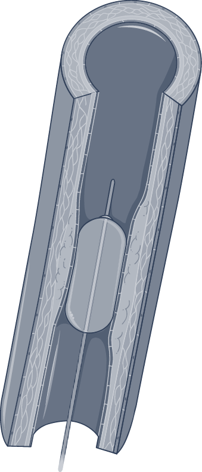

[figure not shown]

**參考文獻 References**

Chen FY. Sac/Val & vascular access flow in HD HFrEF. Clin Kidney J 2025;18(4):sfaf078 (PMID 40226376) · Nguyen DV. ARNI in dialysis SRMA (26 studies). Eur J Heart Fail 2025;27(1):72-84 (PMID 39252524).

§ 05 · Comprehensive Overview

## Cardio-renal protection across the whole spectrum

| CKD stage | Evidence | Cardiac | Renal |
| --- | --- | --- | --- |
| Normal / CKD 1–3 (eGFR ≥30) | PARADIGM-HF sub; by KDIGO tiers | eGFR ≥60: ↓19% · <60: ↓21% CV death / HFH (consistent across tiers) | eGFR +0.43 mL/min/yr; renal HR 0.65 |
| ESKD / Dialysis (<15 / HD) | Nguyen SRMA 2025; Le D 2024; Case C | LVEF ↑8%; mortality ↓36% | ↓29% hyperkalemia; ↑AVF flow |

From de novo HF super-responders to advanced dialysis patients — consistent cardio-renal synergy across the entire spectrum.

**參考文獻 References**

McMurray NEJM 2014 (PMID 25176015) · Chatur S. KDIGO. JACC 2024;83(22):2148-59 (PMID 38588927) · Nguyen DV. Eur J Heart Fail 2025;27(1):72-84 (PMID 39252524) · Le D. JAMA Netw Open 2024;7(8):e2429237 (PMID 39163041).

§ 07 · Evidence-Practice Gap

## Real-world evidence matches — even exceeds — the trials

| Data source | Type · N | Key finding |
| --- | --- | --- |
| Lee WC (Chang Gung) | Claims · 3,735 | ↓ all-cause mortality in HFrEF + CKD (HR 1.46 ACEi/ARB vs ARNI) |
| US Dialysis (Le D) | Claims (JAMA NO) | HR 0.82 mortality on hemodialysis |
| SwedeHF (Fu M) | Registry · 1,506 matched | HR 0.77 all-cause mortality (p=0.013) |
| US Optum (Bhatt) | EHR · >9,000 | ↓19% all-cause hosp (primary); ↓30% mortality (exploratory), de novo HFrEF |
| CHAMP-HF | US Registry · 3,518 | Only 14% on target dose |

>60% of eligible HF patients still not on ARNI. The gap is widest at CKD 3b+, driven by prescriber hesitancy — not by evidence.

**參考文獻 References**

Lee WC. Cardiovasc Drugs Ther 2024;38(3):505-15 (PMID 36609948) · Le D. JAMA Netw Open 2024;7(8):e2429237 (PMID 39163041) · Fu M. SwedeHF. Clin Res Cardiol 2023;112(1):167-74 (PMID 36443599) · Bhatt AS. ESC Heart Fail 2025;12(3):1682-92 (PMID 39888167) · Greene SJ. CHAMP-HF. JACC 2018;72(4):351-66 (PMID 30025570).

§ 08 · Safety Profile

## Safety across the CKD spectrum

| Parameter | ARNI | ACEi/ARB | Significance |
| --- | --- | --- | --- |
| Symptomatic hypotension | Slightly ↑ | Lower | Manageable with dose adj. |
| Hyperkalemia (eGFR ≥30) | Similar | Similar | No increased risk |
| Hyperkalemia (dialysis) | Lower | Higher | 29% reduction |
| Angioedema | 0.5% | 0.2% | Monitor; CI with ACEi |
| Renal function decline | Slower | Faster | eGFR +0.43 mL/min/yr vs enalapril |
| Discontinuation | Lower | Higher | Better tolerability |

#### CKD dosing considerations

- **eGFR 30–60** — standard initiation; monitor K⁺/Cr at 1–2 wks
- **eGFR <30** — low-dose 24/26 mg BID; slow titration 4–8 wks
- **Dialysis** — 24/26 mg BID on non-dialysis days
- **ACEi washout** — 36-hour washout mandatory

In dialysis, hyperkalemia risk falls — not rises.

**參考文獻 References**

Packer M. Circulation 2015;131(1):54-61 (PMID 25403646) · Damman K. JACC Heart Fail 2018;6(6):489-98 (PMID 29655829) · Le D. JAMA Netw Open 2024;7(8):e2429237 (PMID 39163041) · Entresto® Prescribing Information (Novartis) · 2024 ACC ECDP (PMID 38466244).

§ 08 · Daily Practice

## 2024 ACC ECDP — ARNI is first-line

ARNI is the 1st-line Class I therapy for HFrEF. ACEi/ARB only if ARNI is contraindicated or not tolerated.

[output not shown]

#### Titration algorithm

1. Identify eligible HFrEF patient (LVEF ≤40%).
2. Check eGFR, K⁺, SBP → eGFR ≥30, K⁺ <5.2, SBP ≥100 = standard pathway; eGFR <30 or dialysis = low-dose pathway.
3. ACEi washout (36 hours) if applicable.
4. Initiate Entresto — 49/51 mg BID standard · 24/26 mg BID low-dose.
5. Monitor at 1–2 weeks — BP, K⁺, Cr.
6. Up-titrate if tolerated → target 97/103 mg BID.
7. Follow-up — renal function q3–6 months.

**參考文獻 References**

2024 ACC Expert Consensus Decision Pathway (Maddox TM). JACC 2024;83(15):1444-88 (PMID 38466244) · Heidenreich PA. 2022 AHA/ACC/HFSA HF Guideline. Circulation 2022;145(18):e895-e1032 (PMID 35363499) · Entresto® Prescribing Information (Novartis).

§ Closing

## Five things to remember

01

A decade of proven excellence.

PARADIGM-HF established ARNI as the gold standard; subsequent trials and RWE have only strengthened the evidence.

02

New evidence confirms broad benefits.

Japan PREMIER, Swedish nationwide (SwedeHF) and US Optum RWE confirm benefit across populations.

03

Consistent benefit across the CKD spectrum.

From normal eGFR to ESKD on dialysis — cardio-renal protection at every stage.

04

De novo HFrEF — start early.

First-line ARNI in de novo HFrEF cuts all-cause hospitalization by 19% (primary); exploratory mortality signal suggests a 30% reduction (Bhatt 2025).

05

Act now — don't wait.

2024 ACC ECDP positions ARNI as 1st line. Early initiation maximizes reverse remodeling — delay is a choice with consequences.

**參考文獻 References**

McMurray NEJM 2014 (PMID 25176015) · Tanaka EHJ 2024 (PMID 39215531) · Fu SwedeHF (PMID 36443599) · Bhatt US Optum (PMID 39888167) · Nguyen Eur J Heart Fail 2025 (PMID 39252524) · 2024 ACC ECDP (PMID 38466244).

§ Closing

## Ten years. One molecule. A decade of evidence.

#### From PARADIGM to the bedside

From a single landmark trial in 2014 to a decade of evidence spanning HFrEF, preserved-EF heart failure, acute decompensation, CKD stage 3b, and dialysis. From North America to Asia. From the failure of Omapatrilat to ARNI as Class I first-line therapy in 2024.

#### The next ten years

Mu-Yang Hsieh, MD, PhD, FESC · NTUH Hsin-Chu Branch · TSOC 2026  
Anatomical illustrations: Servier Medical Art (smart.servier.com), CC BY 4.0.

§ Evidence Base · PubMed-verified & DOI-linked

## References

1. McMurray JJV, et al. ARNI vs enalapril in HF (PARADIGM-HF). N Engl J Med 2014;371:993-1004. [doi:10.1056/NEJMoa1409077](https://doi.org/10.1056/NEJMoa1409077)
2. Velazquez EJ, et al. Sacubitril/valsartan in acute HF (PIONEER-HF). N Engl J Med 2019;380:539-548. [doi:10.1056/NEJMoa1812851](https://doi.org/10.1056/NEJMoa1812851)
3. Solomon SD, et al. Sacubitril/valsartan in HFpEF (PARAGON-HF). N Engl J Med 2019;381:1609-1620. [doi:10.1056/NEJMoa1908655](https://doi.org/10.1056/NEJMoa1908655)
4. Solomon SD, et al. LCZ696 in HFpEF (PARAMOUNT). Lancet 2012;380:1387-95. doi:10.1016/S0140-6736(12)61227-6
5. Tanaka A, et al. ARNI in admitted worsening HF (PREMIER). Eur Heart J 2024;45:4482-4493. [doi:10.1093/eurheartj/ehae561](https://doi.org/10.1093/eurheartj/ehae561)
6. Doi S, et al. Up-titration of Sac/Val in AHF (PREMIER). J Card Fail 2026;32:573-582. [doi:10.1016/j.cardfail.2025.05.001](https://doi.org/10.1016/j.cardfail.2025.05.001)
7. Taha HI, et al. ARNI in acute decompensated HF: meta-analysis. Future Cardiol 2026;22:43-55. [doi:10.1080/14796678.2025.2535218](https://doi.org/10.1080/14796678.2025.2535218)
8. Mentz RJ, et al. Sac/Val in worsening HFmrEF/HFpEF (PARAGLIDE-HF). J Am Coll Cardiol 2023;82:1-12. [doi:10.1016/j.jacc.2023.04.019](https://doi.org/10.1016/j.jacc.2023.04.019)
9. DeVore AD, et al. PIONEER-HF open-label extension. JAMA Cardiol 2020;5:202-207. [doi:10.1001/jamacardio.2019.4665](https://doi.org/10.1001/jamacardio.2019.4665)
10. Ambrosy AP, et al. Sac/Val in de novo HF (PIONEER-HF). J Am Coll Cardiol 2020;76:1034-1048. [doi:10.1016/j.jacc.2020.06.073](https://doi.org/10.1016/j.jacc.2020.06.073)
11. Wachter R, et al. In-hospital initiation of Sac/Val (TRANSITION). Eur J Heart Fail 2019;21:998-1007. [doi:10.1002/ejhf.1498](https://doi.org/10.1002/ejhf.1498)
12. Pfeffer MA, et al. ARNI after acute MI (PARADISE-MI). N Engl J Med 2021;385:1845-1855. [doi:10.1056/NEJMoa2104508](https://doi.org/10.1056/NEJMoa2104508)
13. Vardeny O, et al. Combined neprilysin & RAS inhibition for HF. JACC Heart Fail 2014;2:663-70. [doi:10.1016/j.jchf.2014.09.001](https://doi.org/10.1016/j.jchf.2014.09.001)
14. Packer M, et al. ARNI effect on HF outcomes (PARADIGM-HF). Circulation 2015;131:54-61. [doi:10.1161/CIRCULATIONAHA.114.013748](https://doi.org/10.1161/CIRCULATIONAHA.114.013748)
15. Packer M, et al. Omapatrilat vs enalapril in HF (OVERTURE). Circulation 2002;106:920-6. [doi:10.1161/01.cir.0000029801.86489.50](https://doi.org/10.1161/01.cir.0000029801.86489.50)
16. Kostis JB, et al. Omapatrilat & angioedema (OCTAVE). Am J Hypertens 2004;17:103-11. [doi:10.1016/j.amjhyper.2003.09.014](https://doi.org/10.1016/j.amjhyper.2003.09.014)
17. Hubers SA, Brown NJ. Neprilysin inhibition & angioedema. Circulation 2016;133:1115-24. [doi:10.1161/CIRCULATIONAHA.115.018622](https://doi.org/10.1161/CIRCULATIONAHA.115.018622)
18. Eadie AL, et al. Sacubitril/valsartan co-crystal pharmacology. Pharmacol Res Perspect 2021;9:e00794. [doi:10.1002/prp2.794](https://doi.org/10.1002/prp2.794)
19. Damman K, et al. Renal effects of ARNI in PARADIGM-HF. JACC Heart Fail 2018;6:489-498. [doi:10.1016/j.jchf.2018.02.004](https://doi.org/10.1016/j.jchf.2018.02.004)
20. Judge P, et al. Neprilysin inhibition in CKD. Nephrol Dial Transplant 2015;30:738-43. [doi:10.1093/ndt/gfu269](https://doi.org/10.1093/ndt/gfu269)
21. Chatur S, et al. Sac/Val across the spectrum of renal impairment (KDIGO). J Am Coll Cardiol 2024;83:2148-2159. [doi:10.1016/j.jacc.2024.03.392](https://doi.org/10.1016/j.jacc.2024.03.392)
22. Haynes R, et al. Sac/Val vs irbesartan in CKD (UK-HARP-III). Circulation 2018;138:1505-1514. [doi:10.1161/CIRCULATIONAHA.118.034818](https://doi.org/10.1161/CIRCULATIONAHA.118.034818)
23. Lee WC, et al. Sacubitril/valsartan in HFrEF with CKD. Cardiovasc Drugs Ther 2024;38:505-515. [doi:10.1007/s10557-022-07421-0](https://doi.org/10.1007/s10557-022-07421-0)
24. Le D, et al. Sac/Val in patients requiring hemodialysis. JAMA Netw Open 2024;7:e2429237. [doi:10.1001/jamanetworkopen.2024.29237](https://doi.org/10.1001/jamanetworkopen.2024.29237)
25. Nguyen DV, et al. ARNI in dialysis: systematic review & meta-analysis. Eur J Heart Fail 2025;27:72-84. [doi:10.1002/ejhf.3454](https://doi.org/10.1002/ejhf.3454)
26. Chang HY, et al. Real-world ARNI in HFrEF with advanced CKD (pooled TSOC-HFrEF + TAROT-HF). Mayo Clin Proc 2023;98(1):88-99. [doi:10.1016/j.mayocp.2022.06.007](https://doi.org/10.1016/j.mayocp.2022.06.007)
27. Greene SJ, et al. Medical therapy for HFrEF (CHAMP-HF). J Am Coll Cardiol 2018;72:351-366. [doi:10.1016/j.jacc.2018.04.070](https://doi.org/10.1016/j.jacc.2018.04.070)
28. Zahir Anjum D, et al. HF therapy initiation by kidney function (Danish nationwide). Clin Epidemiol 2023;15:855-866. [doi:10.2147/CLEP.S412787](https://doi.org/10.2147/CLEP.S412787)
29. Fu M, et al. Real-world ARNI vs ACEi/ARB in HFrEF/HFmrEF (SwedeHF). Clin Res Cardiol 2023;112:167-174. [doi:10.1007/s00392-022-02124-w](https://doi.org/10.1007/s00392-022-02124-w)
30. Bhatt AS, et al. Real-world Sac/Val vs RAS inhibition in de novo HF (US Optum). ESC Heart Fail 2025;12:1682-1692. [doi:10.1002/ehf2.15183](https://doi.org/10.1002/ehf2.15183)
31. Heidenreich PA, et al. 2022 AHA/ACC/HFSA Heart Failure Guideline. Circulation 2022;145:e895-e1032. [doi:10.1161/CIR.0000000000001063](https://doi.org/10.1161/CIR.0000000000001063)
32. Maddox TM, et al. 2024 ACC Expert Consensus Decision Pathway for HFrEF. J Am Coll Cardiol 2024;83:1444-1488. [doi:10.1016/j.jacc.2023.12.024](https://doi.org/10.1016/j.jacc.2023.12.024)
33. Chen FY, et al. Sacubitril/valsartan & vascular access flow (Qa) in hemodialysis HFrEF. Clin Kidney J 2025;18(4):sfaf078. [doi:10.1093/ckj/sfaf078](https://doi.org/10.1093/ckj/sfaf078)